# Regresión lineal y bondad de ajuste

Oscar García Cervantes - Taller de economía cuantitativa V y VI

viernes 21 de octubre, 2022

## 1. Paqueterías

Utilizaremos las siguientes paqueterías: `tidiverse`, `wooldridge` y `broom`

```r
library(tidyverse)
library(wooldridge)
library(broom)
```

La paquetería `wooldridge` nos permite utilizar los datos empleados en ejemplos y en las actividades del libro **Introducción a la econometría** de [**Jeffrey M. Wooldridge**](https://twitter.com/jmwooldridge). Al cargar esta paquetería las bases de datos se encuentran disponibles en la memoria.

## 2. Bases de datos

El conjunto de bases de datos disponibles con la paquetería `wooldridge` se encuentran en el siguiente enlace: https://cran.r-project.org/web/packages/wooldridge/wooldridge.pdf.

Para la interpretación de los coeficientes se recomienda revisar la **Tabla 2.3 Resumen de las formas funcionales en las que se emplean logaritmos** ubicada en la página 46 del de Wooldridge.

## 3. Visualización y regresión lineal

### Ejemplos 3.1 y 3.4 *Determinantes del promedio en la universidad*

Para el ejemplo 3.1 y 3.4 (pp. 75 y 81) utilizamos la base **gpa1**. Como primer paso damos un vistazo a la base.

```r
str(gpa1)
```

```
## 'data.frame':    141 obs. of  29 variables:
##  $ age     : int  21 21 20 19 20 20 22 22 22 19 ...
##  $ soph    : int  0 0 0 1 0 0 0 0 0 1 ...
##  $ junior  : int  0 0 1 0 1 0 0 0 0 0 ...
##  $ senior  : int  1 1 0 0 0 1 0 0 0 0 ...
##  $ senior5 : int  0 0 0 0 0 0 1 1 1 0 ...
##  $ male    : int  0 0 0 1 0 1 0 0 0 0 ...
##  $ campus  : int  0 0 0 1 0 1 0 0 0 0 ...
##  $ business: int  1 1 1 1 1 1 1 0 0 1 ...
##  $ engineer: int  0 0 0 0 0 0 0 0 0 0 ...
##  $ colGPA  : num  3 3.4 3 3.5 3.6 ...
##  $ hsGPA   : num  3 3.2 3.6 3.5 3.9 ...
##  $ ACT     : int  21 24 26 27 28 25 25 22 21 27 ...
##  $ job19   : int  0 0 1 1 0 0 0 1 1 1 ...
##  $ job20   : int  1 1 0 0 1 0 0 0 0 0 ...
```

[output cut: 16 more lines]

```r
summary(gpa1)
```

```
##       age             soph             junior          senior
##  Min.   :19.00   Min.   :0.00000   Min.   :0.000   Min.   :0.0000
##  1st Qu.:20.00   1st Qu.:0.00000   1st Qu.:0.000   1st Qu.:0.0000
##  Median :21.00   Median :0.00000   Median :0.000   Median :1.0000
##  Mean   :20.89   Mean   :0.02128   Mean   :0.383   Mean   :0.5035
##  3rd Qu.:21.00   3rd Qu.:0.00000   3rd Qu.:1.000   3rd Qu.:1.0000
##  Max.   :30.00   Max.   :1.00000   Max.   :1.000   Max.   :1.0000
##     senior5            male            campus          business
##  Min.   :0.0000   Min.   :0.0000   Min.   :0.0000   Min.   :0.0000
##  1st Qu.:0.0000   1st Qu.:0.0000   1st Qu.:0.0000   1st Qu.:1.0000
##  Median :0.0000   Median :1.0000   Median :0.0000   Median :1.0000
##  Mean   :0.0922   Mean   :0.5248   Mean   :0.1702   Mean   :0.7943
##  3rd Qu.:0.0000   3rd Qu.:1.0000   3rd Qu.:0.0000   3rd Qu.:1.0000
##  Max.   :1.0000   Max.   :1.0000   Max.   :1.0000   Max.   :1.0000
##     engineer           colGPA          hsGPA            ACT
##  Min.   :0.00000   Min.   :2.200   Min.   :2.400   Min.   :16.00
##  1st Qu.:0.00000   1st Qu.:2.800   1st Qu.:3.200   1st Qu.:22.00
##  Median :0.00000   Median :3.000   Median :3.400   Median :24.00
##  Mean   :0.03546   Mean   :3.057   Mean   :3.402   Mean   :24.16
##  3rd Qu.:0.00000   3rd Qu.:3.300   3rd Qu.:3.600   3rd Qu.:26.00
##  Max.   :1.00000   Max.   :4.000   Max.   :4.000   Max.   :33.00
##      job19            job20            drive             bike
##  Min.   :0.0000   Min.   :0.0000   Min.   :0.0000   Min.   :0.0000
##  1st Qu.:0.0000   1st Qu.:0.0000   1st Qu.:0.0000   1st Qu.:0.0000
##  Median :0.0000   Median :0.0000   Median :0.0000   Median :0.0000
##  Mean   :0.4113   Mean   :0.1702   Mean   :0.2057   Mean   :0.3617
##  3rd Qu.:1.0000   3rd Qu.:0.0000   3rd Qu.:0.0000   3rd Qu.:1.0000
##  Max.   :1.0000   Max.   :1.0000   Max.   :1.0000   Max.   :1.0000
##       walk           voluntr             PC             greek
##  Min.   :0.0000   Min.   :0.0000   Min.   :0.0000   Min.   :0.0000
##  1st Qu.:0.0000   1st Qu.:0.0000   1st Qu.:0.0000   1st Qu.:0.0000
##  Median :0.0000   Median :0.0000   Median :0.0000   Median :0.0000
##  Mean   :0.4326   Mean   :0.2199   Mean   :0.3972   Mean   :0.3191
##  3rd Qu.:1.0000   3rd Qu.:0.0000   3rd Qu.:1.0000   3rd Qu.:1.0000
##  Max.   :1.0000   Max.   :1.0000   Max.   :1.0000   Max.   :1.0000
##       car           siblings         bgfriend          clubs
##  Min.   :0.000   Min.   :0.0000   Min.   :0.0000   Min.   :0.0000
##  1st Qu.:1.000   1st Qu.:1.0000   1st Qu.:0.0000   1st Qu.:0.0000
##  Median :1.000   Median :1.0000   Median :0.0000   Median :1.0000
##  Mean   :0.773   Mean   :0.9362   Mean   :0.4752   Mean   :0.6028
##  3rd Qu.:1.000   3rd Qu.:1.0000   3rd Qu.:1.0000   3rd Qu.:1.0000
##  Max.   :1.000   Max.   :1.0000   Max.   :1.0000   Max.   :1.0000
##     skipped         alcohol          gradMI          fathcoll
##  Min.   :0.000   Min.   :0.000   Min.   :0.0000   Min.   :0.0000
##  1st Qu.:0.000   1st Qu.:1.000   1st Qu.:1.0000   1st Qu.:0.0000
##  Median :1.000   Median :2.000   Median :1.0000   Median :1.0000
##  Mean   :1.076   Mean   :1.901   Mean   :0.8723   Mean   :0.5887
##  3rd Qu.:2.000   3rd Qu.:3.000   3rd Qu.:1.0000   3rd Qu.:1.0000
##  Max.   :5.000   Max.   :7.000   Max.   :1.0000   Max.   :1.0000
##     mothcoll
##  Min.   :0.000
##  1st Qu.:0.000
##  Median :1.000
##  Mean   :0.539
##  3rd Qu.:1.000
##  Max.   :1.000
```

Tenemos una base de datos con 29 variables y 141 observaciones.

El modelo propuesto en el ejemplo 3.1 es el siguiente:

$$\hat{colGPA}=\beta_0+\beta_1hsGPA+\beta_2ACT+u$$
donde $colGPA$ es el promedio general de calificaciones en la universidad, $hsGPA$ es el promedio general de calificaciones en el bachillerato y $ACT$ es la puntuación en el examen de admisión ala universidad. El modelo predice el promedio general de calificaciones en la universidad, a partir del promedio general de calificaciones en el bachillerato y de la calificación en el examen de admisión.

Primero visualizamos los datos:

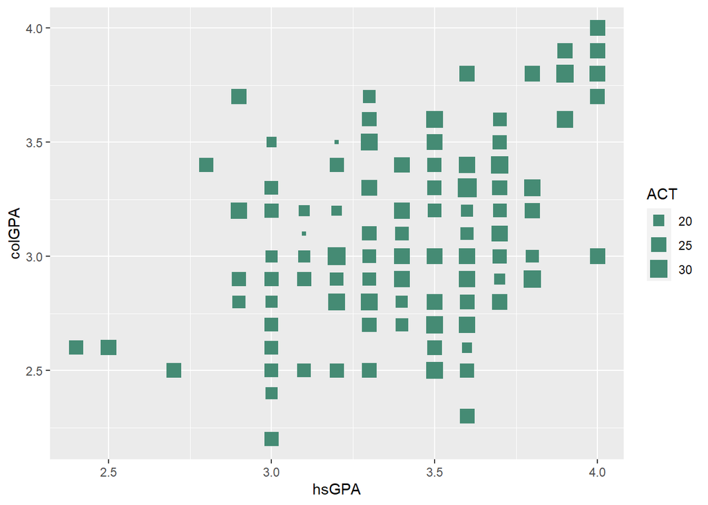

```r
ggplot(gpa1, aes(hsGPA, colGPA, size = ACT)) +
        geom_point(shape = 15, color = "#458B74")
```

Ahora realizamos la estimación mediante MCO:

```r
modelo1 <- lm(colGPA ~ hsGPA + ACT, data = gpa1)
summary(modelo1)
```

```
##
## Call:
## lm(formula = colGPA ~ hsGPA + ACT, data = gpa1)
##
## Residuals:
##      Min       1Q   Median       3Q      Max
## -0.85442 -0.24666 -0.02614  0.28127  0.85357
##
## Coefficients:
##             Estimate Std. Error t value Pr(>|t|)
## (Intercept) 1.286328   0.340822   3.774 0.000238 ***
## hsGPA       0.453456   0.095813   4.733 5.42e-06 ***
## ACT         0.009426   0.010777   0.875 0.383297
## ---
## Signif. codes:  0 '***' 0.001 '**' 0.01 '*' 0.05 '.' 0.1 ' ' 1
##
## Residual standard error: 0.3403 on 138 degrees of freedom
## Multiple R-squared:  0.1764, Adjusted R-squared:  0.1645
## F-statistic: 14.78 on 2 and 138 DF,  p-value: 1.526e-06
```

```r
tidy(modelo1)
```

```
## # A tibble: 3 × 5
##   term        estimate std.error statistic    p.value
##   <chr>          <dbl>     <dbl>     <dbl>      <dbl>
## 1 (Intercept)  1.29       0.341      3.77  0.000238
## 2 hsGPA        0.453      0.0958     4.73  0.00000542
## 3 ACT          0.00943    0.0108     0.875 0.383
```

Obtenemos la siguiente función de regresión:

$$\hat{colGPA}=1.29+0.453hsGPA+0.0094ACT+u$$

Respecto a la bondad de ajuste obtenemos lo siguiente:

```r
glance(modelo1)
```

```
## # A tibble: 1 × 12
##   r.squ…¹ adj.r…² sigma stati…³ p.value    df logLik   AIC   BIC devia…⁴ df.re…⁵
##     <dbl>   <dbl> <dbl>   <dbl>   <dbl> <dbl>  <dbl> <dbl> <dbl>   <dbl>   <int>
## 1   0.176   0.164 0.340    14.8 1.53e-6     2  -46.6  101.  113.    16.0     138
## # … with 1 more variable: nobs <int>, and abbreviated variable names
## #   ¹r.squared, ²adj.r.squared, ³statistic, ⁴deviance, ⁵df.residual
```

La $R^2$ obtenida nos indica que en esta muestra de estudiantes $hsGPA$ y $ACT$ juntos, explican de manera aproximada **17.6%** de la variación en el promedio de calificaciones en la universidad.

### Ejemplo 3.2 *Ecuación para el salario por hora*

- Base: wage1
- Modelo:
  $$\hat{log(wage)}=\beta_0+\beta_1educ+\beta_2exper+\beta_3tenure+u$$
  donde $wage$ corresponde al salario por hora, $educ$ a los años de educación, $exper$ a los años de experiencia en el mercado laboral y $tenure$ a los años de antigüedad en el empleo actual.

Realizamos la estimación miediante el método de MCO:

```r
modelo2 <- lm(log(wage) ~ educ + exper + tenure, data = wage1)
tidy(modelo2)
```

```
## # A tibble: 4 × 5
##   term        estimate std.error statistic  p.value
##   <chr>          <dbl>     <dbl>     <dbl>    <dbl>
## 1 (Intercept)  0.284     0.104        2.73 6.56e- 3
## 2 educ         0.0920    0.00733     12.6  8.82e-32
## 3 exper        0.00412   0.00172      2.39 1.71e- 2
## 4 tenure       0.0221    0.00309      7.13 3.29e-12
```

Obtenemos la siguiente función de regresión:
$$\hat{log(wage)}=.284+.092educ+.0041exper+.022tenure+u$$

Respecto a la bondad de ajuste obtenemos lo siguiente:

```r
glance(modelo2)
```

```
## # A tibble: 1 × 12
##   r.squared adj.r.squa…¹ sigma stati…²  p.value    df logLik   AIC   BIC devia…³
##       <dbl>        <dbl> <dbl>   <dbl>    <dbl> <dbl>  <dbl> <dbl> <dbl>   <dbl>
## 1     0.316        0.312 0.441    80.4 9.13e-43     3  -314.  637.  658.    101.
## # … with 2 more variables: df.residual <int>, nobs <int>, and abbreviated
## #   variable names ¹adj.r.squared, ²statistic, ³deviance
```

La $R^2$ nos indica que en esta muestra las variables independientes *educ, exper y tenure*, de manera conjunta, explican el **31.6%** de la variación en los salarios por hora.

## 4. Actividad en equipos

## Fuente

*Wooldridge, Jeffrey (2015). Introducción a la econometría. Quinta edición. Cengage Learning Editores. México D.F.*